# Prosper Loan Data Exploration

## by Erik Sorensen

## Investigation Overview

The purpose of this exploration is to determine which variables from the [Prosper](https://www.prosper.com) loan dataset influence the annual percentage rate (APR) for a loan.

## Dataset Overview

The dataset is a collection of loan listings, with one entry per loan.

Data include:

- loan status
- loan parameters (e.g. term, amount, interest rate, APR)
- borrower credit-related variables (e.g. employment, credit rating, credit accounts and balances, income, debt),
- Prosper's own risk score and loan rating
- investments in the loan

Primarily of interest are loan parameters, risk scores and borrrower credit-related variables.

## APR Characteristics

- APR ranges from 4.6-42.4%, with a median of 21.5%
- APR shows an approximately normal distribution, with a large peak near 35%

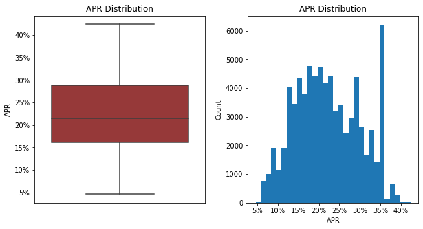

## Loan Characteristics and APR

- Prosper loan rating was by far the most influential variable in determining APR
  - loan rating is comprised of the Prosper score (proprietary multivariate risk score) and credit score
  - loan rating ranges from 1-7 with higher rating associated with less risk
  - loan rating is approximately normally distributed, with a median of 4
- A higher loan rating was associated with a lower APR

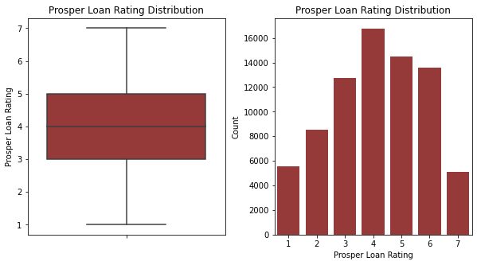

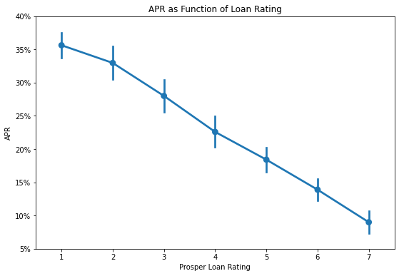

## Loan Characteristics and APR

- Higher loan amount was associated with a lower APR in bivariate analysis
- Median loan amount was \$8,000; the effect on APR was only apparent for loans >\$25,000
  - loans >\$25,000 were only issued to borrowers with a loan rating >= 5
  - when stratified by loan rating, there was no difference in APR between higher and lower loan amounts
- Thus, loan amount did not influence APR when controlling for loan rating

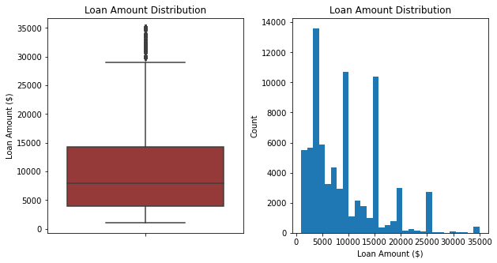

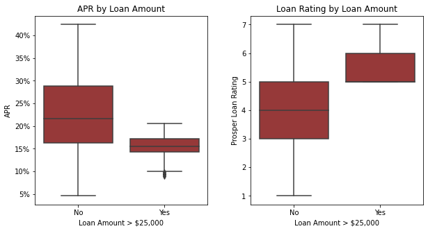

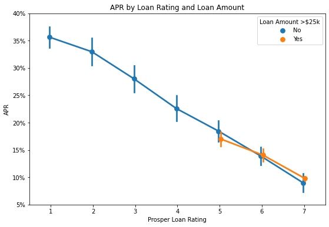

## Loan Characteristics and APR

- Three variables showed minor effects on APR that vanished when stratified by loan rating:
  - debt:income ratio
  - homeowner status
  - prior Prosper loans
- None of the other borrower-related characteristics were associated with APR. Examples:
  - stated monthly income
  - open and current credit lines
  - credit balances
- Representative examples are shown below

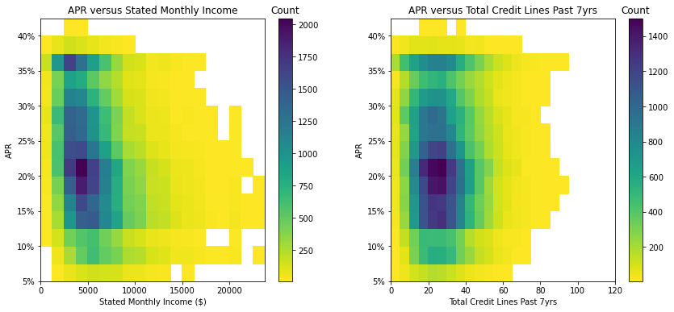

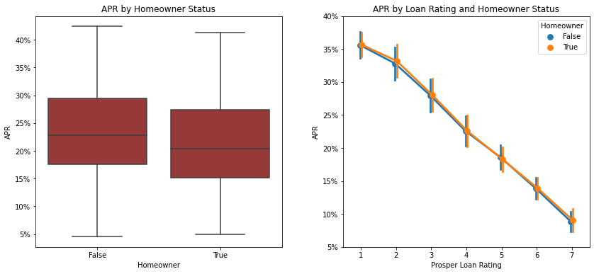

## How do Prosper Score and Credit Score Influence Loan Rating?

- Prosper discloses what the loan rating is comprised of, but not how it is calculated
- Since Prosper loan rating is the primary determinant of APR, it may be of interest to borrowers to know how its constituents influence it
  - At lower Prosper scores, the slope of credit score has less influence on loan rating
  - At higher Prosper scores, the relationship appears more stepwise than linear,
  - The relationships do not appear to be completely monotonic, especially at scores 1-2. This may indicate that the formula is non-linear, or that there are additional factors included that aren't disclosed by Prosper.

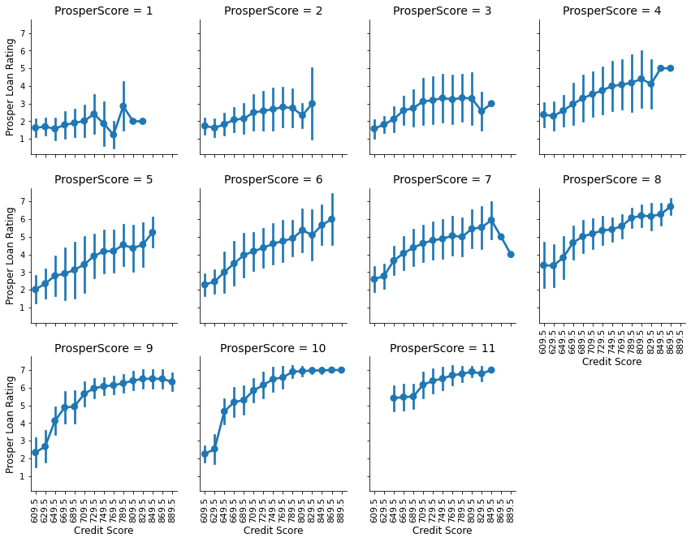

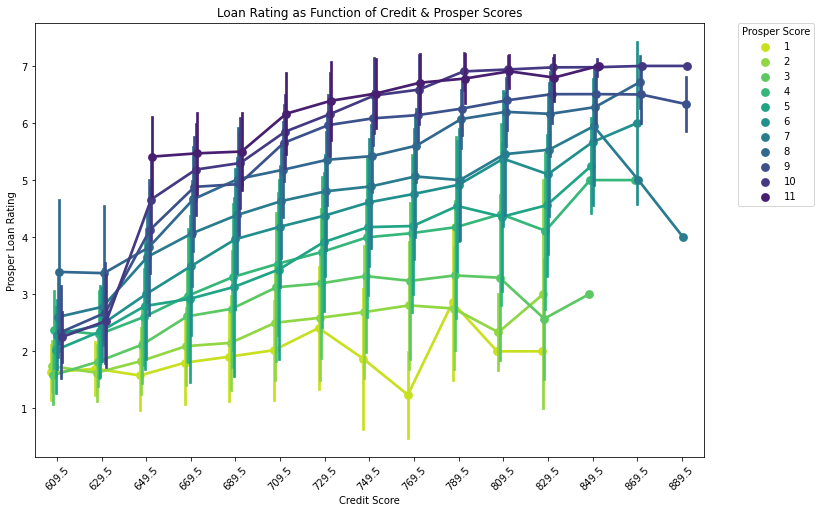